# #tilastoMOOC 2019–2020 **Helsinki Social Statistics** Chapter 10. Regression

Now, pick roles for the variables and start modeling. I predict you are good!

Knitted by **Forename Surname** on 12 December 2019

Chapter 10 consists of 7 exercises: 10.1 – 10.7. Go to each exercise in turn and do as follows:

1. Read the brief description of the exercise.
2. Run the (possible) pre-exercise-code chunk.
3. Follow the instructions to fix the R code!

General information on the MOOC platform (under Theme 1). Have fun! `:-)`

## 10.1 Packages in R

Welcome to chapter 10: **Regression**. We’ll start with an important R feature - packages.

There are a lot of functions in R. But actually, the functions in R come from a standard set of *packages*. A package is simply a collection of R functions. Besides the basic packages, you can install and use (or develop!) other packages too.

You can install packages through CRAN (The Comprehensive R Archive Network). From the CRAN website https://cran.r-project.org/: > CRAN is a network of ftp and web servers around the world that store identical, up-to-date, versions of code and documentation for R.

List of available CRAN packages can be seen [here](https://cran.r-project.org/web/packages/available_packages_by_name.html). There are thousands of them, made by R users around the world. In order to get a package accepted to CRAN, the package must be well documented: every function must have a help page.

As you now have RStudio (and R) in your own computer, you can install R packages anytime by calling `install.packages("name_of_the_package")`. This is best to be done in the Console or in the Packages pane, where there is an Install button.

To use installed packages, you need to access them. This is done by calling `library(name_of_the_package)`.

### R code

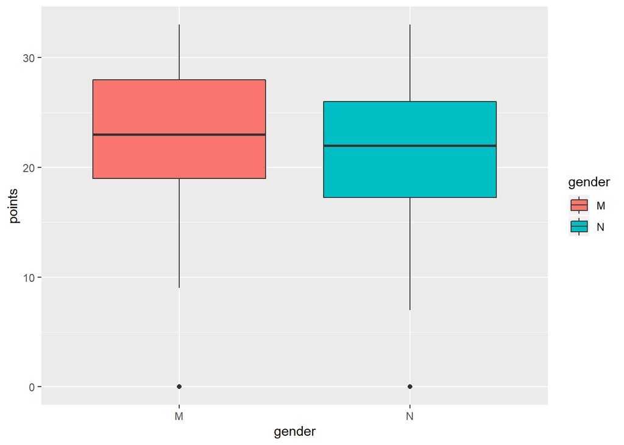

```r
# Work with the exercise in this chunk, step-by-step. Fix the R code!

# learning2014 is available

# Access ggplot2
library(ggplot2)

# Draw a plot of gender and points
qplot(gender, points, data=learning2014, geom="boxplot", fill=gender)
```

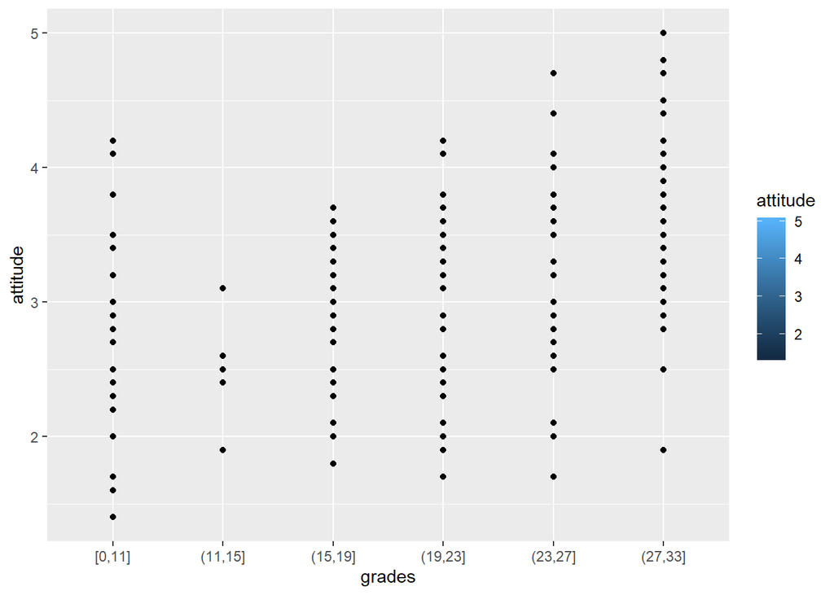

```r
# Create the grades factor
grades <- cut(learning2014$points, breaks = c(0, 11, 15, 19, 23, 27, 33), include.lowest = TRUE)

# Draw a plot of grades and attitude
qplot(grades, attitude, data= learning2014, fill= attitude)
```

You have the keys do anything. Awesome!

## 10.2 Exploring the relationship of two variables

It is always a good idea to start with the simplest possible explorations before more complicated statistical analysis. A scatter plot is always a good starting point when analyzing the relationship between variables. Sample correlations are another useful tool.

In the ggplot2 library, scatter plots can be drawn with the general `qplot()` function. `geom_smooth()` can be used to add a regression line to the plot. In base R `cor.test()` can be used to compute a correlation with a confidence interval.

### Instructions

- Access the ggplot2 library, modify the learning2014 data and draw a scatter plot of `attitude` and `points`.
- Adjust the scatter plot: Add code `+ geom_smooth()` after `qplot()`. Write the code to the same line and do not forget the plus sign. Execute the row.
- Give the function `geom_smooth()` the argument `method = "lm"` and execute the line again. This adds a regression line along with a confidence interval.
- Compute the correlation of `attitude` and `points` with `cor.test()`
- Is a linear relationship between attitude and points plausible?
- How would you characterize the strength of that relationship?

### R code

```r
# Work with the exercise in this chunk, step-by-step. Fix the R code!

# learning2014 is available

# Access ggplot2 functions
library(ggplot2)

# Exlude students who did not attend any exams (points == 0)
learning2014 <- learning2014[learning2014$points != 0, ]

# Create objects attitude and points
attitude <- learning2014$attitude
points <- learning2014$points

# A scatter plot of attitude and points
qplot(attitude, points) + geom_smooth(method= "lm")
```

[output not shown]

```r
# Correlation with a confidence intervals
cor.test(attitude, points)
```

```
##
##  Pearson's product-moment correlation
##
## data:  attitude and points
## t = 6.2135, df = 164, p-value = 4.119e-09
## alternative hypothesis: true correlation is not equal to 0
## 95 percent confidence interval:
##  0.3044463 0.5521335
## sample estimates:
##       cor
## 0.4365245
```

## 10.3 What is a linear model?

Genrally, a [statistical model](https://en.wikipedia.org/wiki/Statistical_model) embodies a set of assumptions concerning the generation of the observed data and similar data from a larger population. A [linear model](https://en.wikipedia.org/wiki/Linear_regression) makes the following assumptions:

- The mean of the response variable is a *linear combination* of the explanatory variable(s) and the parameters.
- The prediction errors of the model are normally distributed.
- The deviation in prediction errors is constant over possible values of the explanatory variable(s).

Regression analysis is based on a linear model - a simple statistical model in which a linear relationship between the mean of the variable of interest (`y`) and some explanatory variable(s) (`x`) is assumed:

$$y = a + b \cdot x + errors$$

where `a` and `b` are unknown parameters to be estimated (a is called the *intercept* and b the *regression coefficient*).

### Instructions

- Create some toy data, choose the parameters, produce random errors and form the linear model between `x` and `y`
- Draw a scatterplot of `x` and `y` using `plot()`.
- Compute the correlation of `x` and `y`
- The *coefficient of determination* (also called “R squared” - does not refer to the R program, however!) is the correlation squared. Compute it.
- Change the parameter $b$ of the linear model to -1.5 and repeat the above computations.

### R code

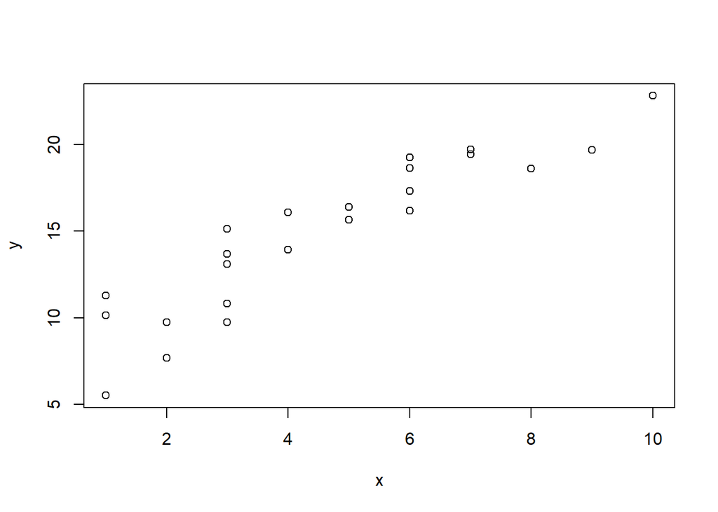

```r
# Work with the exercise in this chunk, step-by-step. Fix the R code!

# Here we produce data from a linear model where we choose the parameters

# Create some toy data
x <- c(1,3,7,3,5,8,2,3,10,9,4,5,6,1,2,4,6,6,7,6,3,3,1)

# Choose the parameters and produce random errors
a <- 7
b <- 1.5
e <- rnorm(length(x), sd = 2)

# A linear model for y
y <- a + b*x + e

# Scatter plot of x and y
plot(x,y)
```

```r
# Correlation (R)
cor(x,y)
```

```
## [1] 0.9152238
```

```r
# Coefficient of determination (R squared)
cor(x,y)^2
```

```
## [1] 0.8376346
```